# W3cubDocs

/scikit-learn

# sklearn.decomposition.FastICA

**`class sklearn.decomposition.FastICA(n_components=None, algorithm=’parallel’, whiten=True, fun=’logcosh’, fun_args=None, max_iter=200, tol=0.0001, w_init=None, random_state=None)` [[source]](https://github.com/scikit-learn/scikit-learn/blob/bac89c2/sklearn/decomposition/fastica_.py#L385)**

FastICA: a fast algorithm for Independent Component Analysis.

Read more in the User Guide.

[output not shown]

#### Notes

Implementation based on `A. Hyvarinen and E. Oja, Independent Component Analysis: Algorithms and Applications, Neural Networks, 13(4-5), 2000, pp. 411-430`

#### Examples

```
>>> from sklearn.datasets import load_digits
>>> from sklearn.decomposition import FastICA
>>> X, _ = load_digits(return_X_y=True)
>>> transformer = FastICA(n_components=7,
...         random_state=0)
>>> X_transformed = transformer.fit_transform(X)
>>> X_transformed.shape
(1797, 7)
```

#### Methods

| `fit`(X[, y]) | Fit the model to X. |
| --- | --- |
| `fit_transform`(X[, y]) | Fit the model and recover the sources from X. |
| `get_params`([deep]) | Get parameters for this estimator. |
| `inverse_transform`(X[, copy]) | Transform the sources back to the mixed data (apply mixing matrix). |
| `set_params`(**params) | Set the parameters of this estimator. |
| `transform`(X[, y, copy]) | Recover the sources from X (apply the unmixing matrix). |

**`__init__(n_components=None, algorithm=’parallel’, whiten=True, fun=’logcosh’, fun_args=None, max_iter=200, tol=0.0001, w_init=None, random_state=None)` [[source]](https://github.com/scikit-learn/scikit-learn/blob/bac89c2/sklearn/decomposition/fastica_.py#L465)**

**`fit(X, y=None)` [[source]](https://github.com/scikit-learn/scikit-learn/blob/bac89c2/sklearn/decomposition/fastica_.py#L538)**

Fit the model to X.

| Parameters: | **`X : array-like, shape (n_samples, n_features)`** Training data, where n_samples is the number of samples and n_features is the number of features. **`y : Ignored`** |
| --- | --- |
| Returns: | **self** |

**`fit_transform(X, y=None)` [[source]](https://github.com/scikit-learn/scikit-learn/blob/bac89c2/sklearn/decomposition/fastica_.py#L521)**

Fit the model and recover the sources from X.

| Parameters: | **`X : array-like, shape (n_samples, n_features)`** Training data, where n_samples is the number of samples and n_features is the number of features. **`y : Ignored`** |
| --- | --- |
| Returns: | **`X_new : array-like, shape (n_samples, n_components)`** |

**`get_params(deep=True)` [[source]](https://github.com/scikit-learn/scikit-learn/blob/bac89c2/sklearn/base.py#L166)**

Get parameters for this estimator.

| Parameters: | **`deep : boolean, optional`** If True, will return the parameters for this estimator and contained subobjects that are estimators. |
| --- | --- |
| Returns: | **`params : mapping of string to any`** Parameter names mapped to their values. |

**`inverse_transform(X, copy=True)` [[source]](https://github.com/scikit-learn/scikit-learn/blob/bac89c2/sklearn/decomposition/fastica_.py#L587)**

Transform the sources back to the mixed data (apply mixing matrix).

[output not shown]

**`set_params(**params)` [[source]](https://github.com/scikit-learn/scikit-learn/blob/bac89c2/sklearn/base.py#L189)**

Set the parameters of this estimator.

The method works on simple estimators as well as on nested objects (such as pipelines). The latter have parameters of the form `<component>__<parameter>` so that it’s possible to update each component of a nested object.

| Returns: | **self** |
| --- | --- |

**`transform(X, y=’deprecated’, copy=True)` [[source]](https://github.com/scikit-learn/scikit-learn/blob/bac89c2/sklearn/decomposition/fastica_.py#L556)**

Recover the sources from X (apply the unmixing matrix).

[output not shown]

## Examples using `sklearn.decomposition.FastICA`

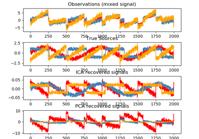

Blind source separation using FastICA

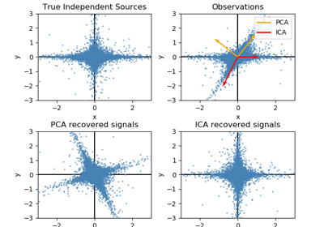

FastICA on 2D point clouds

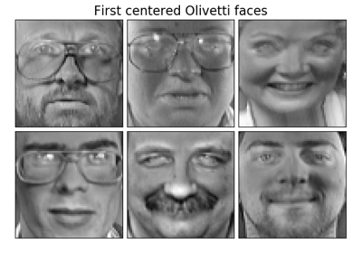

Faces dataset decompositions

© 2007–2018 The scikit-learn developers  
Licensed under the 3-clause BSD License.  
http://scikit-learn.org/stable/modules/generated/sklearn.decomposition.FastICA.html